# Testing Differences

## Variables

- Dependent variable (a.k.a. $DV$, a.k.a. $Y$): The variable that *depends on* the independent variable
- Independent variable (a.k.a. $IV$, a.k.a. $X$): The variable whose variation we’re interested in
- E.g., Does depression symptom severity (DV) *depend on* gender (IV)?
- E.g., Do grades (DV) *depend on* depression symptom severity (IV)?

## Testing Differences

- *t*-Test: Testing differences in means between 1-2 groups
- ANOVA: Testing differences in means between 2+ groups
- Chi-Square Test: Testing differences in proportions

## Getting Started

```r
# Load packages
library(tidyverse)
library(here)

# Load data
hms_data <- readRDS(here("Healthy Minds Study", "Clean Data.rds"))

# Clean data
clean_data <- hms_data %>%
  drop_na()

# Describe data
str(clean_data)
```

```
tibble [76,769 x 21] (S3: tbl_df/tbl/data.frame)
 $ age                   : num [1:76769] 20 26 18 22 36 21 19 26 29 19 ...
 $ gender                : chr [1:76769] "Male" "Male" "Male" "Female" ...
 $ race_black            : logi [1:76769] FALSE FALSE FALSE FALSE FALSE FALSE ...
 $ race_american_indian  : logi [1:76769] FALSE FALSE FALSE FALSE FALSE FALSE ...
 $ race_asian            : logi [1:76769] TRUE FALSE FALSE FALSE FALSE FALSE ...
 $ race_hispanic_latinx  : logi [1:76769] FALSE TRUE FALSE TRUE TRUE FALSE ...
 $ race_pacific_islander : logi [1:76769] FALSE FALSE FALSE FALSE FALSE FALSE ...
 $ race_mideast          : logi [1:76769] FALSE FALSE FALSE TRUE FALSE FALSE ...
 $ race_white            : logi [1:76769] FALSE FALSE FALSE TRUE FALSE TRUE ...
 $ race_other            : logi [1:76769] FALSE FALSE TRUE FALSE FALSE FALSE ...
 $ citizen               : logi [1:76769] TRUE TRUE TRUE TRUE TRUE TRUE ...
 $ financial_stress      : num [1:76769] 2 3 4 4 5 3 3 3 5 2 ...
 $ weekly_hours_paid_work: num [1:76769] 10 0 0 62 40 28.5 40 7 25 0 ...
 $ grades                : chr [1:76769] "Mostly A's" "No grade or don't know" "Mostly A's" "Mostly A's" ...
 $ belonging             : num [1:76769] 6 6 3 3 5 2 5 4 2 6 ...
 $ depression            : num [1:76769] 0 0 1 1 1 0 0 0 0 0 ...
 $ depression_severity   : num [1:76769] 4 3 25 16 20 2 0 2 9 14 ...
 $ anxiety               : num [1:76769] 0 0 1 1 1 0 0 0 1 1 ...
 $ anxiety_severity      : num [1:76769] 6 0 20 16 19 1 0 4 10 14 ...
 $ past_year_therapy     : num [1:76769] 0 0 0 1 0 1 0 0 1 0 ...
 $ past_year_medication  : num [1:76769] 0 0 0 0 1 0 0 1 1 1 ...
```

## *t*-Test

A *t*-test tests differences between means. There are multiple versions of the *t*-test

- One-sample *t*-test
- Two-sample *t*-test
- Paired-samples *t*-test

## One-Sample *t*-Test

One-sample *t*-test: Compares a mean to a pre-specified number (e.g., Does the average college student work more than 10 hours per week?)

- $\mu_1 =$ mean hours worked per week
- $h_0: \mu_1 \le 10$
- $h_1: \mu_1 > 10$

## Two-Sample *t*-Test

Two-sample *t*-test: Compares two means from two different groups to one another (e.g., Does the average number of hours worked per week differ between male and female college students?)

- $DV:$ hours worked per week
- $IV:$ gender (male or female)
- $\mu_1:$ mean hours worked per week among male students
- $\mu_2:$ mean hours worked per week among female students
- $h_0: \mu1 = \mu2$
- $h_1: \mu_1 \ne \mu_2$

## Paired-Samples *t*-Test

Paired-samples *t*-test: Compares two means from the same group (e.g., Do college students experience less severe depression symptoms after they go through therapy?)

- $DV:$ depression symptom severity
- $IV:$ time-point (before or after therapy)
- $\mu_1:$ mean depression symptom severity after therapy
- $\mu_2:$ mean depression symptom severity before therapy
- $h_0: \mu1 \ge \mu2$
- $h_1: \mu_1 < \mu_2$

## Example: Two-Sample *t*-Test

RQ: Does the average amount of financial stress differ between male and female college students?

- $DV:$ financial stress
- $IV:$ gender (male or female)
- $\mu_1:$ mean level of financial stress among male students
- $\mu_2:$ mean level of financial stress among female students
- $h_0: \mu_1 = \mu_2$
- $h_1: \mu_1 \ne \mu_2$

## The Means

- $\mu_1:$ mean level of financial stress among male students
- $\mu_2:$ mean level of financial stress among female students

```r
financial_stress_men <- clean_data$financial_stress[clean_data$gender == "Male"]
summary(financial_stress_men)
```

```
   Min. 1st Qu.  Median    Mean 3rd Qu.    Max.
  1.000   2.000   3.000   2.999   4.000   5.000
```

```r
financial_stress_women <- clean_data$financial_stress[clean_data$gender == "Female"]
summary(financial_stress_women)
```

```
   Min. 1st Qu.  Median    Mean 3rd Qu.    Max.
  1.000   3.000   3.000   3.255   4.000   5.000
```

## The Distributions

Both sample distributions should be approximately normally distributed.

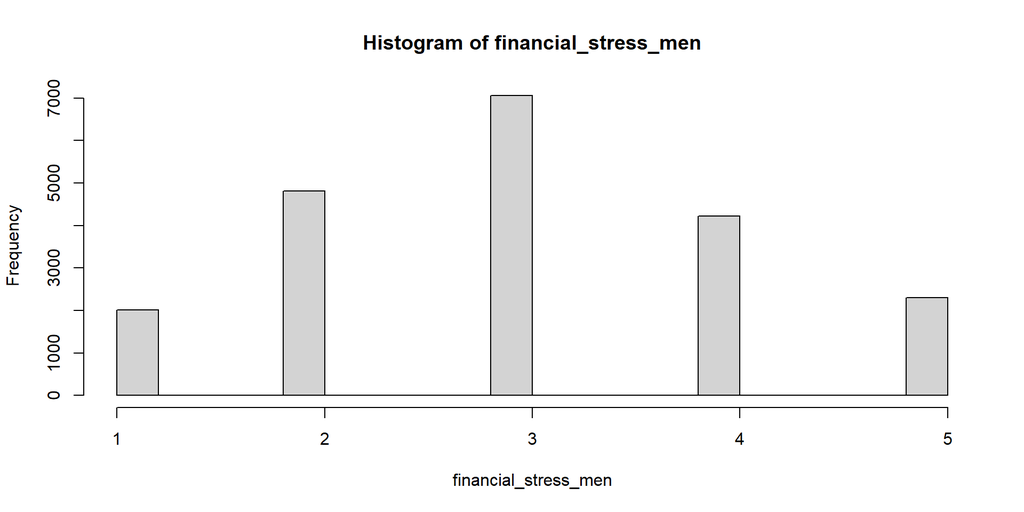

```r
hist(financial_stress_men)
```

## The Distributions

Both sample distributions should be approximately normally distributed.

```r
hist(financial_stress_women)
```

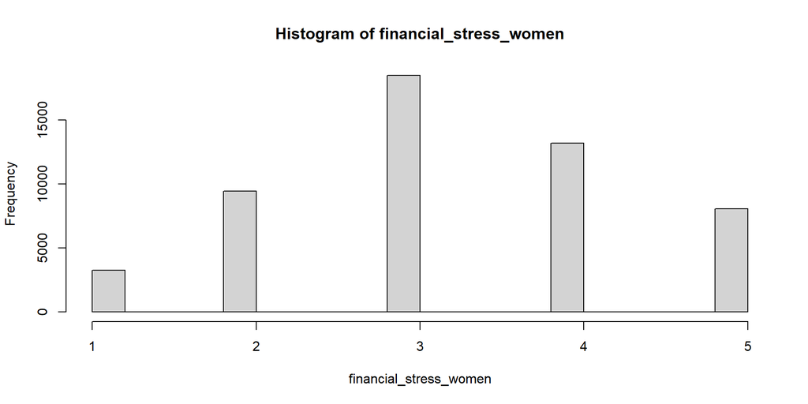

## The Analysis

We have our *sample* means. We have our *sample* distributions. What do we need to test whether these differences hold up in the *population*?

We need to know what we would see if we took *many different* samples. We need **sampling distributions**!

## Sampling Distribution of $\mu_1$

```r
mean_financial_stress_men <- mean(financial_stress_men)
print(mean_financial_stress_men)
```

```
[1] 2.998627
```

```r
sd_financial_stress_men <- sd(financial_stress_men)
print(sd_financial_stress_men)
```

```
[1] 1.135519
```

```r
n_men <- length(financial_stress_men)
print(n_men)
```

```
[1] 20398
```

```r
se_financial_stress_men <- sd_financial_stress_men / sqrt(n_men)
print(se_financial_stress_men)
```

```
[1] 0.007950613
```

```r
sampling_distribution_men <- rnorm(
  n = 100000,
  mean = mean_financial_stress_men,
  sd = se_financial_stress_men
)
```

## Sampling Distribution of $\mu_1$

```r
tibble(sampling_distribution_men) %>%
  ggplot(aes(x = sampling_distribution_men)) +
  geom_density(binwidth = .001) +
  geom_vline(aes(xintercept = mean_financial_stress_men + (1.96 * se_financial_stress_men))) +
  geom_vline(aes(xintercept = mean_financial_stress_men - (1.96 * se_financial_stress_men)))
```

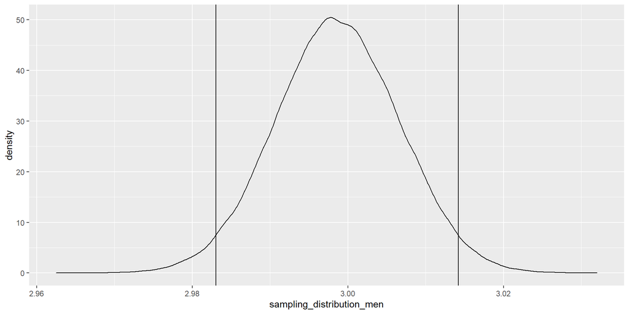

## Sampling Distribution of $\mu_2$

```r
mean_financial_stress_women <- mean(financial_stress_women)
print(mean_financial_stress_women)
```

```
[1] 3.254878
```

```r
sd_financial_stress_women <- sd(financial_stress_women)
print(sd_financial_stress_women)
```

```
[1] 1.108965
```

```r
n_women <- length(financial_stress_women)
print(n_women)
```

```
[1] 52378
```

```r
se_financial_stress_women <- sd_financial_stress_women / sqrt(n_women)
print(se_financial_stress_women)
```

```
[1] 0.004845552
```

```r
sampling_distribution_women <- rnorm(
  n = 100000,
  mean = mean_financial_stress_women,
  sd = se_financial_stress_women
)
```

## Sampling Distribution of $\mu_2$

```r
tibble(sampling_distribution_women) %>%
  ggplot(aes(x = sampling_distribution_women)) +
  geom_density(binwidth = .001) +
  geom_vline(aes(xintercept = mean_financial_stress_women + (1.96 * se_financial_stress_women))) +
  geom_vline(aes(xintercept = mean_financial_stress_women - (1.96 * se_financial_stress_women)))
```

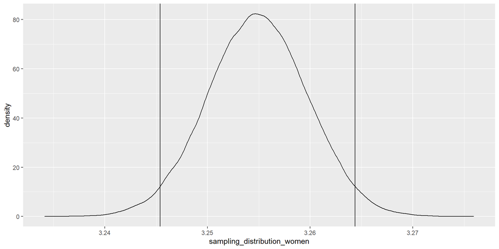

## Comparison of Sampling Distributions

```r
tibble(
  sample_mean = c(sampling_distribution_men, sampling_distribution_women),
  x1 = c(rep("men", length(sampling_distribution_men)), rep("women", length(sampling_distribution_women)))
) %>%
  ggplot(aes(x = sample_mean, group = x1, color = x1, fill = x1)) +
  geom_density(binwidth = .001)
```

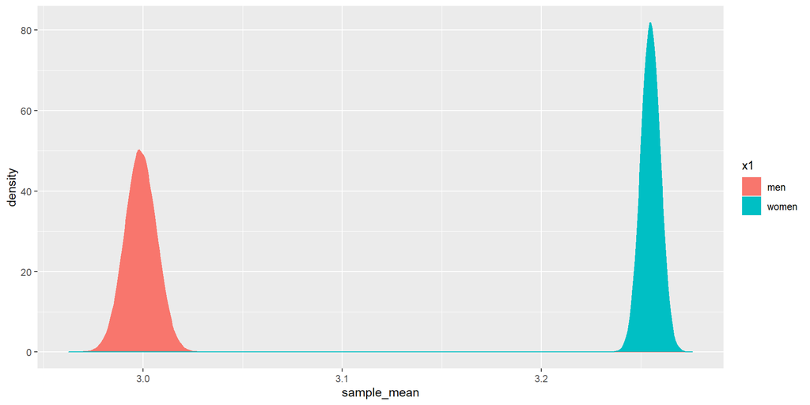

## The *t*-Statistic

We just reviewed the sampling distributions for our $\mu_1$ and $\mu_2$ statistics. The *t*-statistic represents the difference between the sample means, and has its own sampling distribution.

$t = \dfrac{\bar{x}_1 - \bar{x}_2}{se_{pooled}}$

$t=0$ when there is no difference in means

## The *t*-Statistic

```r
difference_in_means <- mean_financial_stress_men - mean_financial_stress_women
print(difference_in_means)
```

```
[1] -0.2562507
```

```r
se_pooled <- t.test(x = financial_stress_men, y = financial_stress_women)$stderr
print(se_pooled)
```

```
[1] 0.009310834
```

```r
t <- difference_in_means / se_pooled
print(t)
```

```
[1] -27.52178
```

## The *t*-Distribution Under $h_0$

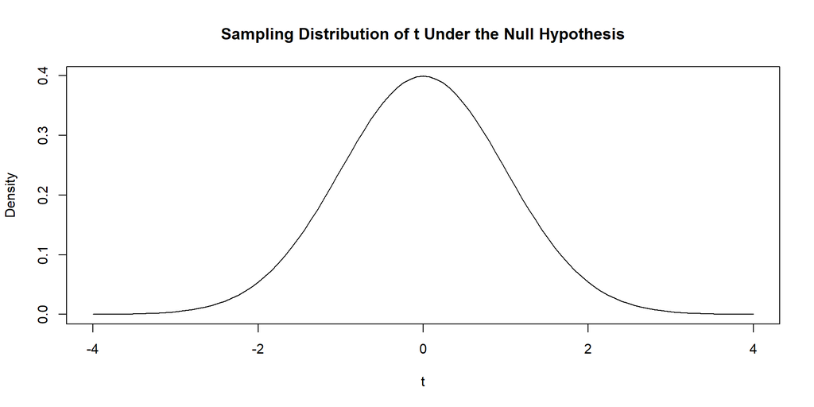

## The Test

```r
t.test(
  x = financial_stress_men,
  y = financial_stress_women
)
```

```
    Welch Two Sample t-test

data:  financial_stress_men and financial_stress_women
t = -27.522, df = 36407, p-value < 2.2e-16
alternative hypothesis: true difference in means is not equal to 0
95 percent confidence interval:
 -0.2745002 -0.2380012
sample estimates:
mean of x mean of y
 2.998627  3.254878
```

## The Test (Again)

```r
t.test(
  data = clean_data,
  financial_stress ~ gender,
  subset = gender %in% c("Male", "Female")
)
```

```
    Welch Two Sample t-test

data:  financial_stress by gender
t = 27.522, df = 36407, p-value < 2.2e-16
alternative hypothesis: true difference in means between group Female and group Male is not equal to 0
95 percent confidence interval:
 0.2380012 0.2745002
sample estimates:
mean in group Female   mean in group Male
            3.254878             2.998627
```

## Reporting the Test

In our sample, women experienced more financial stress (mean = 3.25, s.d. = 1.11) than men (mean = 3.00, s.d. = 1.13). We used a *t*-test to test whether this sample difference reflects a true difference in the population means. Our null hypothesis was that there would be no difference in population means. Our alternative hypothesis was that there would be some difference in population means. With a *p*-value < .001, we reject the null hypothesis and conclude that there is a true difference in the population means.

## Visualizing the Difference

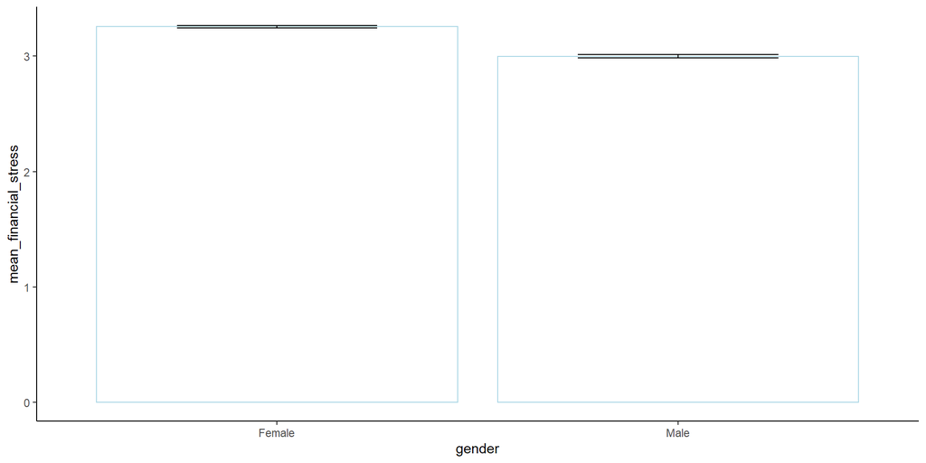

## ANOVA

ANOVA (short for “ANalysis Of VAriance”) is used to test differences in means between 2+ groups

## Example: ANOVA

RQ: Does the average amount of financial stress depend on student gender (3 categories: male, female, and trans/gender diverse)?

- $DV:$ financial stress
- $IV:$ gender (male, female, or trans/gender diverse)
- $\mu_1, \mu_2, \mu_3:$ mean level of financial stress among male, female, and trans/gender diverse students
- $h_0: \mu_1 = \mu_2 = \mu_3$
- $h_1: \mu_1 \ne \mu_2$ or $\mu_1 \ne \mu_3$ or $\mu_2 \ne \mu_3$

## The Means

- $\mu_1:$ mean level of financial stress among male students
- $\mu_2:$ mean level of financial stress among female students
- $\mu_3:$ mean level of financial stress among trans/gender diverse students

```r
financial_stress_tgd <- clean_data$financial_stress[clean_data$gender == "Trans/Gender-Diverse"]
summary(financial_stress_tgd)
```

```
   Min. 1st Qu.  Median    Mean 3rd Qu.    Max.
  1.000   3.000   3.000   3.395   4.000   5.000
```

```r
summary(financial_stress_men)
```

```
   Min. 1st Qu.  Median    Mean 3rd Qu.    Max.
  1.000   2.000   3.000   2.999   4.000   5.000
```

```r
summary(financial_stress_women)
```

```
   Min. 1st Qu.  Median    Mean 3rd Qu.    Max.
  1.000   3.000   3.000   3.255   4.000   5.000
```

## The *F*-Statistic

The “*F*-statistic” represents the ratio of variance *across* groups to the variance *within* groups. Like any statistic, it has its own sampling distribution.

$F = \dfrac{var_{across}}{var_{within}}$

$F=1$ when there is just as much variability within groups as there is across groups

## The *F*-Distribution Under $h_0$

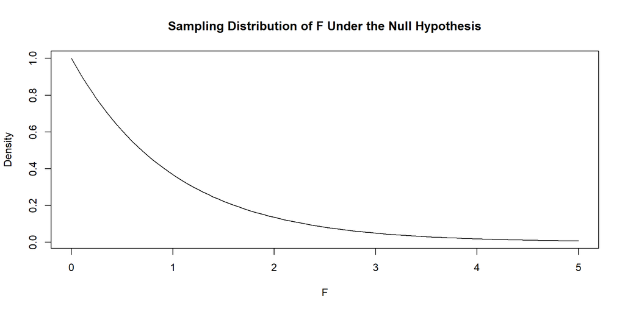

## The Test

```r
financial_stress_by_gender <- aov(
  data = clean_data,
  formula = financial_stress ~ gender
)

summary(financial_stress_by_gender)
```

```
               Df Sum Sq Mean Sq F value Pr(>F)
gender          2   1134   567.2   454.4 <2e-16 ***
Residuals   76766  95808     1.2
---
Signif. codes:  0 '***' 0.001 '**' 0.01 '*' 0.05 '.' 0.1 ' ' 1
```

If the null hypothesis were true, what how likely would we be to see an *F*-statistic at least as large as 454.4?

## Reporting the Test

In our sample, trans and gender diverse students experienced the most financial stress (mean = 3.39, s.d. = 1.13), then women (mean = 3.25, s.d. = 1.11), then men (mean = 3.00, s.d. = 1.13). We used ANOVA to test whether these sample differences reflect a true differences in the population means. Our null hypothesis was that there would be no difference in population means. Our alternative hypothesis was that there would be some difference in population means. With a *p*-value < .001, we reject the null hypothesis and conclude that there is a true difference in the population mean of financial stress by gender.

## Visualizing the Difference

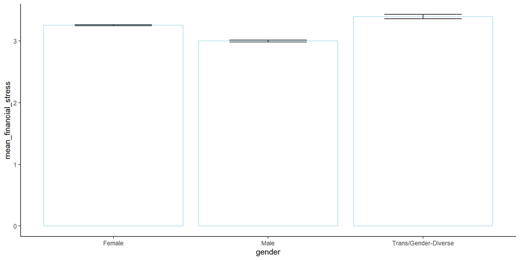

## Chi-Square Test

The Chi-Square test is used is used to test differences in proportions across any number of groups

## Example: Chi-Square Test

RQ: Does the frequency of anxiety depend on student’s typical grades?

- $DV:$ anxiety (present or absent)
- $IV:$ student grades (A’s, B’s, etc.)
- $h_0:$ the frequency of anxiety does not depend on a student’s grades
- $h_1$: the frequency of anxiety *does* depend on a student’s grades

## The Table

```r
anxiety_by_grades <- table(clean_data$anxiety, clean_data$grades)
print(anxiety_by_grades)
```

```
    Mostly A's Mostly B's Mostly C's Mostly D's Mostly F's
  0      34770       8858       1235        102         37
  1      19550       6750       1389        175         75

    No grade or don't know None of these
  0                   2177           219
  1                   1333            99
```

## The Table (Again)

```r
clean_data %>%
  group_by(grades) %>%
  summarize(proportion_anxious = mean(anxiety))
```

```
# A tibble: 7 x 2
  grades                 proportion_anxious
  <chr>                               <dbl>
1 Mostly A's                          0.360
2 Mostly B's                          0.432
3 Mostly C's                          0.529
4 Mostly D's                          0.632
5 Mostly F's                          0.670
6 No grade or don't know              0.380
7 None of these                       0.311
```

The Chi-Square Statistic

The “chi square statistic” represents the difference between the observed frequency of our $DV$ at different levels of the $IV$, and what we would expect to see if there was no relationship between the two variables. Like any statistic, it has its own sampling distribution.

$\chi^2 = \sum\dfrac{(observed-expected)^2}{expected}$

$\chi^2$ is higher when there is a bigger difference between the observed and expected frequencies

## The *Chi-Square* Distribution Under $h_0$

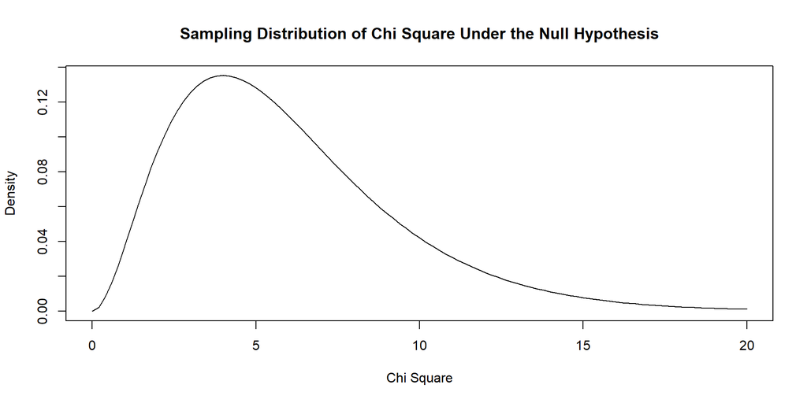

## The Test

```r
chisq.test(anxiety_by_grades)
```

```
    Pearson's Chi-squared test

data:  anxiety_by_grades
X-squared = 640.83, df = 6, p-value < 2.2e-16
```

If the null hypothesis were true, what how likely would we be to see a chi square statistic at least as large as 640.8?

## Reporting the Test

In our sample, students with worse grades tended to experience anxiety more frequently. For example, 36% of students who typically received A’s had clinical levels of anxiety symptoms, while 67% of students who typically receive F’s did. We used a chi square test to test whether this sample difference reflects a true difference in the population proportions. Our null hypothesis was that there the frequency of anxiety does not depend on grades in the full population. Our alternative hypothesis was that the frequency of anxiety *does* depend on grades in the full population. With a *p*-value < .001, we reject the null hypothesis and conclude that the frequency of anxiety really does depend on grades among the full population of college students.

## Visualizing the Difference

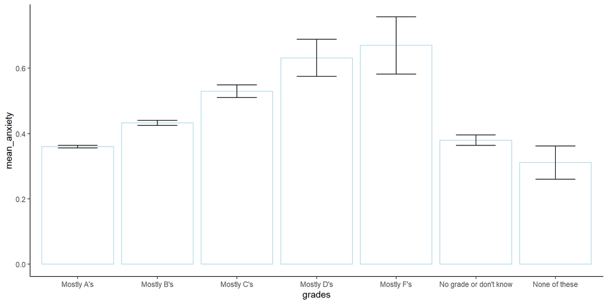